# Project 2

Roger Wang

2026-04-05

# Import Data

```r
library(arrow)
library(dplyr)
library(tidyr)

#files <- choose.files()

files <- list.files("C:/Users/sheng/Downloads", pattern = "\\.parquet$", full.names = TRUE)

basename(files) #making sure the correct files are grabbed.
```

```
##  [1] "yellow_tripdata_2025-01.parquet" "yellow_tripdata_2025-02.parquet"
##  [3] "yellow_tripdata_2025-03.parquet" "yellow_tripdata_2025-04.parquet"
##  [5] "yellow_tripdata_2025-05.parquet" "yellow_tripdata_2025-06.parquet"
##  [7] "yellow_tripdata_2025-07.parquet" "yellow_tripdata_2025-08.parquet"
##  [9] "yellow_tripdata_2025-09.parquet" "yellow_tripdata_2025-10.parquet"
## [11] "yellow_tripdata_2025-11.parquet" "yellow_tripdata_2025-12.parquet"
```

```r
#sampling 5% from each month
taxi <- bind_rows(
  lapply(seq_along(files), function(i) {
    f <- files[i]

    # extract month
    month_val <- as.integer(sub(".*-(\\d{2})\\.parquet", "\\1", basename(f)))

    set.seed(123)

    read_parquet(f) %>%
      sample_frac(0.05, replace = FALSE) %>%
      mutate(month = month_val)
  })
)


head(taxi)
```

```
## # A tibble: 6 × 21
##   VendorID tpep_pickup_datetime tpep_dropoff_datetime passenger_count
##      <int> <dttm>               <dttm>                          <int>
## 1        1 2025-01-22 15:34:30  2025-01-22 16:34:32                 1
## 2        2 2025-01-24 18:25:44  2025-01-24 18:37:40                NA
## 3        2 2025-01-02 12:02:02  2025-01-02 13:01:21                 1
## 4        2 2025-01-22 12:46:17  2025-01-22 13:02:06                NA
## 5        2 2025-01-30 10:48:40  2025-01-30 10:57:24                 1
## 6        2 2025-01-26 07:19:09  2025-01-26 07:19:22                NA
## # ℹ 17 more variables: trip_distance <dbl>, RatecodeID <int>,
## #   store_and_fwd_flag <chr>, PULocationID <int>, DOLocationID <int>,
## #   payment_type <int>, fare_amount <dbl>, extra <dbl>, mta_tax <dbl>,
## #   tip_amount <dbl>, tolls_amount <dbl>, improvement_surcharge <dbl>,
## #   total_amount <dbl>, congestion_surcharge <dbl>, Airport_fee <dbl>,
## #   cbd_congestion_fee <dbl>, month <int>
```

```r
nrow(taxi) # Total of 2436130 records
```

```
## [1] 2436130
```

```r
summary(taxi)
```

```
##     VendorID     tpep_pickup_datetime          tpep_dropoff_datetime
##  Min.   :1.000   Min.   :2024-12-31 17:51:20   Min.   :2024-12-31 18:00:00
##  1st Qu.:2.000   1st Qu.:2025-04-08 08:49:02   1st Qu.:2025-04-08 09:06:40
##  Median :2.000   Median :2025-07-03 07:04:50   Median :2025-07-03 07:24:00
##  Mean   :1.861   Mean   :2025-07-06 00:51:38   Mean   :2025-07-06 01:08:58
##  3rd Qu.:2.000   3rd Qu.:2025-10-06 09:06:11   3rd Qu.:2025-10-06 09:24:52
##  Max.   :7.000   Max.   :2025-12-31 17:59:36   Max.   :2026-01-01 11:48:24
##
##  passenger_count  trip_distance         RatecodeID     store_and_fwd_flag
##  Min.   :0.00     Min.   :0.000e+00   Min.   : 1.00    Length:2436130
##  1st Qu.:1.00     1st Qu.:1.040e+00   1st Qu.: 1.00    Class :character
##  Median :1.00     Median :1.850e+00   Median : 1.00    Mode  :character
##  Mean   :1.29     Mean   :6.275e+00   Mean   : 3.23
##  3rd Qu.:1.00     3rd Qu.:3.700e+00   3rd Qu.: 1.00
##  Max.   :9.00     Max.   :2.741e+05   Max.   :99.00
##  NA's   :580571                       NA's   :580571
##   PULocationID    DOLocationID    payment_type     fare_amount
##  Min.   :  1.0   Min.   :  1.0   Min.   :0.0000   Min.   :-1807.60
##  1st Qu.:114.0   1st Qu.:107.0   1st Qu.:1.0000   1st Qu.:    8.60
##  Median :161.0   Median :162.0   Median :1.0000   Median :   13.58
##  Mean   :161.6   Mean   :161.1   Mean   :0.9369   Mean   :   18.38
##  3rd Qu.:233.0   3rd Qu.:233.0   3rd Qu.:1.0000   3rd Qu.:   22.60
##  Max.   :265.0   Max.   :265.0   Max.   :4.0000   Max.   : 1777.50
##
##      extra           mta_tax          tip_amount        tolls_amount
##  Min.   :-7.500   Min.   :-5.7500   Min.   :-150.990   Min.   :-90.0000
##  1st Qu.: 0.000   1st Qu.: 0.5000   1st Qu.:   0.000   1st Qu.:  0.0000
##  Median : 0.000   Median : 0.5000   Median :   2.000   Median :  0.0000
##  Mean   : 1.164   Mean   : 0.4777   Mean   :   2.841   Mean   :  0.4983
##  3rd Qu.: 2.500   3rd Qu.: 0.5000   3rd Qu.:   3.990   3rd Qu.:  0.0000
##  Max.   :16.190   Max.   :10.5000   Max.   : 960.940   Max.   :141.1800
##
##  improvement_surcharge  total_amount      congestion_surcharge  Airport_fee
##  Min.   :-1.0000       Min.   :-1832.85   Min.   :-2.50        Min.   :-1.75
##  1st Qu.: 1.0000       1st Qu.:   15.74   1st Qu.: 2.50        1st Qu.: 0.00
##  Median : 1.0000       Median :   21.35   Median : 2.50        Median : 0.00
##  Mean   : 0.9504       Mean   :   26.86   Mean   : 2.18        Mean   : 0.15
##  3rd Qu.: 1.0000       3rd Qu.:   30.75   3rd Qu.: 2.50        3rd Qu.: 0.00
##  Max.   : 1.0000       Max.   : 1793.37   Max.   : 2.50        Max.   : 6.75
##                                           NA's   :580571       NA's   :580571
##  cbd_congestion_fee     month
##  Min.   :-0.7500    Min.   : 1.000
##  1st Qu.: 0.0000    1st Qu.: 4.000
##  Median : 0.7500    Median : 7.000
##  Mean   : 0.5294    Mean   : 6.649
##  3rd Qu.: 0.7500    3rd Qu.:10.000
##  Max.   : 1.5000    Max.   :12.000
##
```

# Adding Labels for Vendor, Rate Code, and Payment Type

```r
taxi <- taxi %>%
  mutate(
    # Vendor labels
    Vendor_name = case_when(
      VendorID == 1 ~ "Creative Mobile Technologies",
      VendorID == 2 ~ "Curb Mobility",
      VendorID == 6 ~ "Myle Technologies",
      VendorID == 7 ~ "Helix",
      TRUE ~ "Unknown"
    ),

    # Rate code labels
    Ratecode_name = case_when(
      RatecodeID == 1 ~ "Standard",
      RatecodeID == 2 ~ "JFK",
      RatecodeID == 3 ~ "Newark",
      RatecodeID == 4 ~ "Nassau/Westchester",
      RatecodeID == 5 ~ "Negotiated",
      RatecodeID == 6 ~ "Group ride",
      RatecodeID == 99 ~ "Unknown",
      TRUE ~ "Unknown"
    ),

    # Payment type labels
    payment_type_name = case_when(
      payment_type == 0 ~ "Flex fare",
      payment_type == 1 ~ "Credit card",
      payment_type == 2 ~ "Cash",
      payment_type == 3 ~ "No charge",
      payment_type == 4 ~ "Dispute",
      payment_type == 5 ~ "Unknown",
      payment_type == 6 ~ "Voided trip",
      TRUE ~ "Unknown"
    )
  )

head(taxi)
```

```
## # A tibble: 6 × 24
##   VendorID tpep_pickup_datetime tpep_dropoff_datetime passenger_count
##      <int> <dttm>               <dttm>                          <int>
## 1        1 2025-01-22 15:34:30  2025-01-22 16:34:32                 1
## 2        2 2025-01-24 18:25:44  2025-01-24 18:37:40                NA
## 3        2 2025-01-02 12:02:02  2025-01-02 13:01:21                 1
## 4        2 2025-01-22 12:46:17  2025-01-22 13:02:06                NA
## 5        2 2025-01-30 10:48:40  2025-01-30 10:57:24                 1
## 6        2 2025-01-26 07:19:09  2025-01-26 07:19:22                NA
## # ℹ 20 more variables: trip_distance <dbl>, RatecodeID <int>,
## #   store_and_fwd_flag <chr>, PULocationID <int>, DOLocationID <int>,
## #   payment_type <int>, fare_amount <dbl>, extra <dbl>, mta_tax <dbl>,
## #   tip_amount <dbl>, tolls_amount <dbl>, improvement_surcharge <dbl>,
## #   total_amount <dbl>, congestion_surcharge <dbl>, Airport_fee <dbl>,
## #   cbd_congestion_fee <dbl>, month <int>, Vendor_name <chr>,
## #   Ratecode_name <chr>, payment_type_name <chr>
```

# Checking missing values

## A few variables have a large number of missing entries (580,571 NAs out of 2436130 records), including:passenger_count, RatecodeID, store_and_fwd_flag, congestion_surcharge, Airport_fee

```r
#Checking missing values
sapply(taxi, function(x) sum(is.na(x)))
```

```
##              VendorID  tpep_pickup_datetime tpep_dropoff_datetime
##                     0                     0                     0
##       passenger_count         trip_distance            RatecodeID
##                580571                     0                580571
##    store_and_fwd_flag          PULocationID          DOLocationID
##                580571                     0                     0
##          payment_type           fare_amount                 extra
##                     0                     0                     0
##               mta_tax            tip_amount          tolls_amount
##                     0                     0                     0
## improvement_surcharge          total_amount  congestion_surcharge
##                     0                     0                580571
##           Airport_fee    cbd_congestion_fee                 month
##                580571                     0                     0
##           Vendor_name         Ratecode_name     payment_type_name
##                     0                     0                     0
```

# Section: Missing Passenger Count Analysis by Vendor

## Question: How does missing passenger count data vary across taxi vendors

## Myle Technologies has 100% missing data, which suggests a systematic issue rather than random missingness. In contrast, Creative Mobile Technologies (16.4%) and Curb Mobility (26%) have moderate levels of missing data, while Helix has no missing values at all.

## Question: How are passenger counts distributed across different vendors?

## Most trips across all vendors have a passenger count of 1, with higher counts (6–9) being rare outliers. Curb Mobility shows slightly more variability, but overall patterns are similar across vendors.

```r
taxi %>%
  count(Vendor_name, missing = is.na(passenger_count)) %>%
  pivot_wider(names_from = missing, values_from = n, values_fill = 0) %>%
  mutate(
    total = `FALSE` + `TRUE`,
    missing_pct = `TRUE` / total * 100
  )
```

```
## # A tibble: 4 × 5
##   Vendor_name                  `FALSE` `TRUE`   total missing_pct
##   <chr>                          <int>  <int>   <int>       <dbl>
## 1 Creative Mobile Technologies  400624  78514  479138        16.4
## 2 Curb Mobility                1427777 500819 1928596        26.0
## 3 Helix                          27158      0   27158         0
## 4 Myle Technologies                  0   1238    1238       100
```

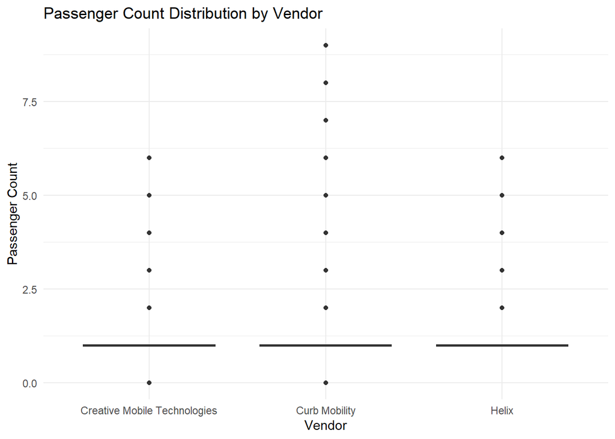

```r
library(ggplot2)

taxi %>%
  filter(!is.na(passenger_count)) %>%
  ggplot(aes(x = Vendor_name, y = passenger_count)) +
  geom_boxplot() +
  labs(
    title = "Passenger Count Distribution by Vendor",
    x = "Vendor",
    y = "Passenger Count"
  ) +
  theme_minimal()
```

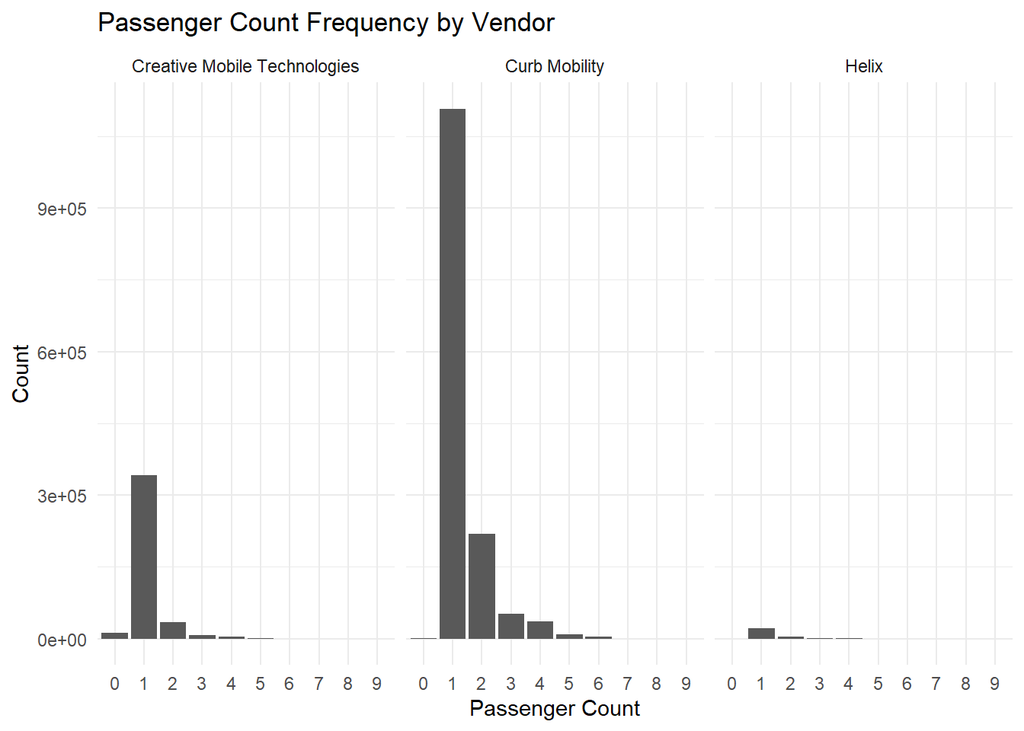

```r
taxi %>%
  filter(!is.na(passenger_count)) %>%
  ggplot(aes(x = factor(passenger_count))) +
  geom_bar() +
  facet_wrap(~Vendor_name) +
  labs(
    title = "Passenger Count Frequency by Vendor",
    x = "Passenger Count",
    y = "Count"
  ) +
  theme_minimal()
```

# Question: How should missing passenger count data be handled?

## This suggests the missingness is vendor-specific, not random. So I imputed missing passenger counts as 1 for non-Myle vendors (since 1 is most common), but avoided doing so for Myle to prevent bias.

```r
taxi <- taxi %>%
  mutate(
    passenger_count_missing = is.na(passenger_count),
    passenger_count = ifelse(
      is.na(passenger_count) & Vendor_name != "Myle Technologies",
      1,
      passenger_count
    )
  )

head(taxi)
```

```
## # A tibble: 6 × 25
##   VendorID tpep_pickup_datetime tpep_dropoff_datetime passenger_count
##      <int> <dttm>               <dttm>                          <dbl>
## 1        1 2025-01-22 15:34:30  2025-01-22 16:34:32                 1
## 2        2 2025-01-24 18:25:44  2025-01-24 18:37:40                 1
## 3        2 2025-01-02 12:02:02  2025-01-02 13:01:21                 1
## 4        2 2025-01-22 12:46:17  2025-01-22 13:02:06                 1
## 5        2 2025-01-30 10:48:40  2025-01-30 10:57:24                 1
## 6        2 2025-01-26 07:19:09  2025-01-26 07:19:22                 1
## # ℹ 21 more variables: trip_distance <dbl>, RatecodeID <int>,
## #   store_and_fwd_flag <chr>, PULocationID <int>, DOLocationID <int>,
## #   payment_type <int>, fare_amount <dbl>, extra <dbl>, mta_tax <dbl>,
## #   tip_amount <dbl>, tolls_amount <dbl>, improvement_surcharge <dbl>,
## #   total_amount <dbl>, congestion_surcharge <dbl>, Airport_fee <dbl>,
## #   cbd_congestion_fee <dbl>, month <int>, Vendor_name <chr>,
## #   Ratecode_name <chr>, payment_type_name <chr>, …
```

# Section: Impact of Missing Passenger Count on Tip Analysis

## Question: Does missing passenger count data affect tip amounts?

```r
# Whole dataset
taxi %>%
  summarise(
    mean_tip = mean(tip_amount, na.rm = TRUE),
    median_tip = median(tip_amount, na.rm = TRUE),
    min_tip = min(tip_amount, na.rm = TRUE),
    max_tip = max(tip_amount, na.rm = TRUE)
  )
```

```
## # A tibble: 1 × 4
##   mean_tip median_tip min_tip max_tip
##      <dbl>      <dbl>   <dbl>   <dbl>
## 1     2.84          2   -151.    961.
```

```r
# Excluding missing passenger_count
taxi %>%
  filter(!is.na(passenger_count)) %>%
  summarise(
    mean_tip = mean(tip_amount, na.rm = TRUE),
    median_tip = median(tip_amount, na.rm = TRUE),
    min_tip = min(tip_amount, na.rm = TRUE),
    max_tip = max(tip_amount, na.rm = TRUE)
  )
```

```
## # A tibble: 1 × 4
##   mean_tip median_tip min_tip max_tip
##      <dbl>      <dbl>   <dbl>   <dbl>
## 1     2.84          2   -151.    961.
```

# Section: Handling Missing Surcharge and Airport Fee Values

## Question: How prevalent are missing values in surcharge-related variables, and how should I treat them?

## Both variables have many missing values but most entries are valid. I treated missing values as no fee applied and replaced them with 0, allowing me to keep all observations without bias.

```r
taxi %>%
  summarise(
    congestion_non_na = sum(!is.na(congestion_surcharge)),
    congestion_na = sum(is.na(congestion_surcharge)),
    airport_non_na = sum(!is.na(Airport_fee)),
    airport_na = sum(is.na(Airport_fee))
  )
```

```
## # A tibble: 1 × 4
##   congestion_non_na congestion_na airport_non_na airport_na
##               <int>         <int>          <int>      <int>
## 1           1855559        580571        1855559     580571
```

```r
taxi <- taxi %>%
  mutate(
    congestion_surcharge = replace_na(congestion_surcharge, 0),
    Airport_fee = replace_na(Airport_fee, 0)
  )
```

# Section: Data Consistency Checks and Fare Cleaning

## Question: Are there inconsistencies between fare and total amount, and how should I clean them?

## I checked for inconsistencies by identifying records with non-positive fares or totals, which are likely invalid. I removed observations where fare_amount ≤ 0 to ensure only meaningful trips remain.

##I then calculated tip percentage using fare_amount, since total_amount includes tips and extra fees and could distort results. After cleaning, the median tip percentage is ~20% and the mean ~18.8%, though some extreme outliers remain. ##Overall, using fare_amount provides a cleaner, more consistent basis for analysis and reduces the impact of irregularities in total_amount.

```r
# Case 1 count
taxi %>%
  filter(fare_amount <= 0) %>%
  nrow()
```

```
## [1] 143787
```

```r
# Case 2 count
taxi %>%
  filter(total_amount <= 0) %>%
  nrow()
```

```
## [1] 49055
```

```r
taxi <- taxi %>% filter(fare_amount > 0)

taxi <- taxi %>% mutate(tip_percent_fare_amount = tip_amount / fare_amount)

summary(taxi)
```

```
##     VendorID     tpep_pickup_datetime          tpep_dropoff_datetime
##  Min.   :1.000   Min.   :2024-12-31 17:51:20   Min.   :2024-12-31 18:00:00
##  1st Qu.:2.000   1st Qu.:2025-04-07 04:10:20   1st Qu.:2025-04-07 04:28:59
##  Median :2.000   Median :2025-07-02 10:09:37   Median :2025-07-02 10:25:09
##  Mean   :1.852   Mean   :2025-07-05 16:21:13   Mean   :2025-07-05 16:38:32
##  3rd Qu.:2.000   3rd Qu.:2025-10-06 06:32:59   3rd Qu.:2025-10-06 06:52:29
##  Max.   :7.000   Max.   :2025-12-31 17:59:36   Max.   :2026-01-01 11:48:24
##
##  passenger_count trip_distance         RatecodeID     store_and_fwd_flag
##  Min.   :0.000   Min.   :0.000e+00   Min.   : 1.00    Length:2292343
##  1st Qu.:1.000   1st Qu.:1.040e+00   1st Qu.: 1.00    Class :character
##  Median :1.000   Median :1.830e+00   Median : 1.00    Mode  :character
##  Mean   :1.232   Mean   :5.917e+00   Mean   : 3.27
##  3rd Qu.:1.000   3rd Qu.:3.620e+00   3rd Qu.: 1.00
##  Max.   :9.000   Max.   :2.741e+05   Max.   :99.00
##  NA's   :1161                        NA's   :477696
##   PULocationID    DOLocationID    payment_type     fare_amount
##  Min.   :  1.0   Min.   :  1.0   Min.   :0.0000   Min.   :   0.01
##  1st Qu.:116.0   1st Qu.:108.0   1st Qu.:1.0000   1st Qu.:   9.30
##  Median :161.0   Median :162.0   Median :1.0000   Median :  14.36
##  Mean   :162.1   Mean   :161.6   Mean   :0.9352   Mean   :  20.14
##  3rd Qu.:233.0   3rd Qu.:234.0   3rd Qu.:1.0000   3rd Qu.:  23.58
##  Max.   :265.0   Max.   :265.0   Max.   :4.0000   Max.   :1777.50
##
##      extra           mta_tax          tip_amount       tolls_amount
##  Min.   :-3.250   Min.   :-5.7500   Min.   :  0.000   Min.   :  0.0000
##  1st Qu.: 0.000   1st Qu.: 0.5000   1st Qu.:  0.000   1st Qu.:  0.0000
##  Median : 0.000   Median : 0.5000   Median :  2.350   Median :  0.0000
##  Mean   : 1.256   Mean   : 0.4934   Mean   :  3.019   Mean   :  0.5278
##  3rd Qu.: 2.500   3rd Qu.: 0.5000   3rd Qu.:  4.070   3rd Qu.:  0.0000
##  Max.   :16.190   Max.   :10.5000   Max.   :960.940   Max.   :141.1800
##
##  improvement_surcharge  total_amount     congestion_surcharge  Airport_fee
##  Min.   :0.0000        Min.   :   0.00   Min.   :0.000        Min.   :0.0000
##  1st Qu.:1.0000        1st Qu.:  16.70   1st Qu.:0.000        1st Qu.:0.0000
##  Median :1.0000        Median :  22.05   Median :2.500        Median :0.0000
##  Mean   :0.9825        Mean   :  28.91   Mean   :1.802        Mean   :0.1238
##  3rd Qu.:1.0000        3rd Qu.:  31.62   3rd Qu.:2.500        3rd Qu.:0.0000
##  Max.   :1.0000        Max.   :1793.37   Max.   :2.500        Max.   :6.7500
##
##  cbd_congestion_fee     month        Vendor_name        Ratecode_name
##  Min.   :-0.7500    Min.   : 1.000   Length:2292343     Length:2292343
##  1st Qu.: 0.0000    1st Qu.: 4.000   Class :character   Class :character
##  Median : 0.7500    Median : 7.000   Mode  :character   Mode  :character
##  Mean   : 0.5459    Mean   : 6.638
##  3rd Qu.: 0.7500    3rd Qu.:10.000
##  Max.   : 1.2500    Max.   :12.000
##
##  payment_type_name  passenger_count_missing tip_percent_fare_amount
##  Length:2292343     Mode :logical           Min.   :0.000e+00
##  Class :character   FALSE:1814647           1st Qu.:0.000e+00
##  Mode  :character   TRUE :477696            Median :2.097e-01
##                                             Mean   :1.881e-01
##                                             3rd Qu.:2.888e-01
##                                             Max.   :2.000e+04
##
```

```r
head(taxi)
```

```
## # A tibble: 6 × 26
##   VendorID tpep_pickup_datetime tpep_dropoff_datetime passenger_count
##      <int> <dttm>               <dttm>                          <dbl>
## 1        1 2025-01-22 15:34:30  2025-01-22 16:34:32                 1
## 2        2 2025-01-24 18:25:44  2025-01-24 18:37:40                 1
## 3        2 2025-01-02 12:02:02  2025-01-02 13:01:21                 1
## 4        2 2025-01-22 12:46:17  2025-01-22 13:02:06                 1
## 5        2 2025-01-30 10:48:40  2025-01-30 10:57:24                 1
## 6        2 2025-01-26 07:19:09  2025-01-26 07:19:22                 1
## # ℹ 22 more variables: trip_distance <dbl>, RatecodeID <int>,
## #   store_and_fwd_flag <chr>, PULocationID <int>, DOLocationID <int>,
## #   payment_type <int>, fare_amount <dbl>, extra <dbl>, mta_tax <dbl>,
## #   tip_amount <dbl>, tolls_amount <dbl>, improvement_surcharge <dbl>,
## #   total_amount <dbl>, congestion_surcharge <dbl>, Airport_fee <dbl>,
## #   cbd_congestion_fee <dbl>, month <int>, Vendor_name <chr>,
## #   Ratecode_name <chr>, payment_type_name <chr>, …
```

# Section: Tipping Behavior by Payment Type

## Question: How does average tip percentage vary by payment type, and which payment methods have the highest and lowest tipping rates?

## Answer: Tip percentages vary by payment type: credit cards have the highest (~27.2%), flex fare is low (~1.7%), and cash appears near zero due to unrecorded tips. “Dispute” and “No charge” are excluded as they don’t reflect real tipping behavior, leaving credit cards with clearly higher recorded tips than flex fare.

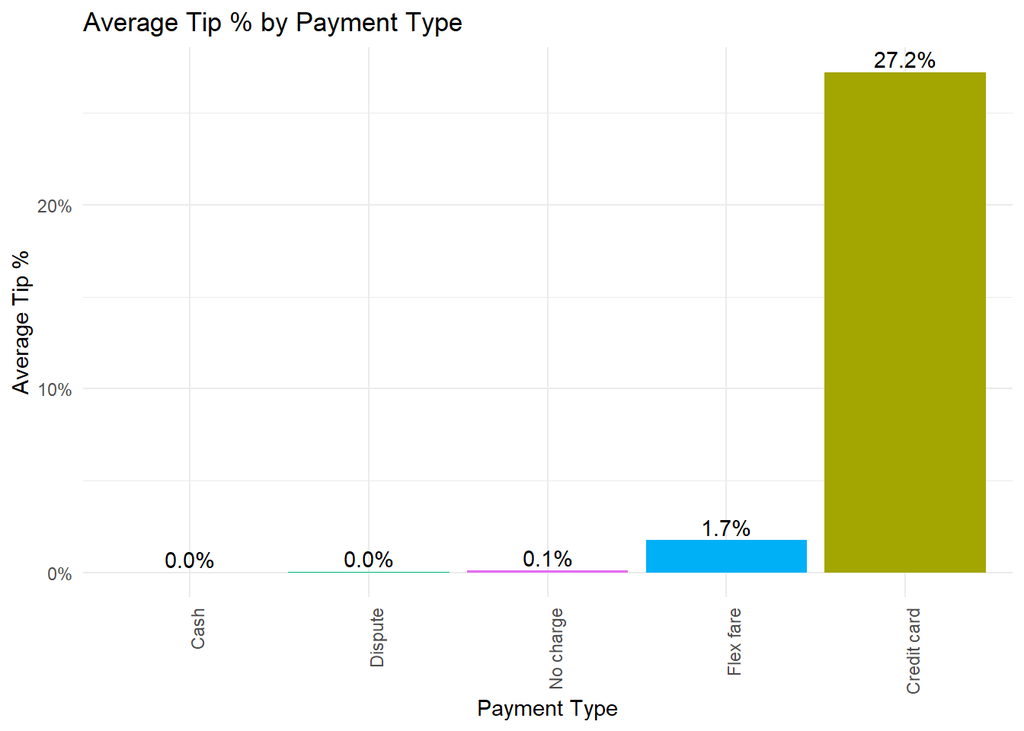

```r
library(ggplot2)
library(scales)

#Payment type
taxi %>%
  group_by(payment_type_name) %>%
  summarise(
    avg_tip = mean(tip_percent_fare_amount, na.rm = TRUE),
    .groups = "drop"
  ) %>%
  ggplot(aes(x = reorder(payment_type_name, avg_tip), y = avg_tip, fill = payment_type_name)) +
  geom_col() +
  geom_text(aes(label = percent(avg_tip, accuracy = 0.1)), vjust = -0.3) +
  scale_y_continuous(labels = percent_format()) +
  labs(
    title = "Average Tip % by Payment Type",
    x = "Payment Type",
    y = "Average Tip %"
  ) +
  theme_minimal() +
  theme(axis.text.x = element_text(angle = 90, hjust = 1),
        legend.position = "none")
```

```r
#  Only keep Flex fare, Credit card
taxi <- taxi %>%
  filter(payment_type_name %in% c("Flex fare", "Credit card"))

head(taxi)
```

```
## # A tibble: 6 × 26
##   VendorID tpep_pickup_datetime tpep_dropoff_datetime passenger_count
##      <int> <dttm>               <dttm>                          <dbl>
## 1        1 2025-01-22 15:34:30  2025-01-22 16:34:32                 1
## 2        2 2025-01-24 18:25:44  2025-01-24 18:37:40                 1
## 3        2 2025-01-02 12:02:02  2025-01-02 13:01:21                 1
## 4        2 2025-01-22 12:46:17  2025-01-22 13:02:06                 1
## 5        2 2025-01-26 07:19:09  2025-01-26 07:19:22                 1
## 6        2 2025-01-19 02:19:57  2025-01-19 02:21:14                 1
## # ℹ 22 more variables: trip_distance <dbl>, RatecodeID <int>,
## #   store_and_fwd_flag <chr>, PULocationID <int>, DOLocationID <int>,
## #   payment_type <int>, fare_amount <dbl>, extra <dbl>, mta_tax <dbl>,
## #   tip_amount <dbl>, tolls_amount <dbl>, improvement_surcharge <dbl>,
## #   total_amount <dbl>, congestion_surcharge <dbl>, Airport_fee <dbl>,
## #   cbd_congestion_fee <dbl>, month <int>, Vendor_name <chr>,
## #   Ratecode_name <chr>, payment_type_name <chr>, …
```

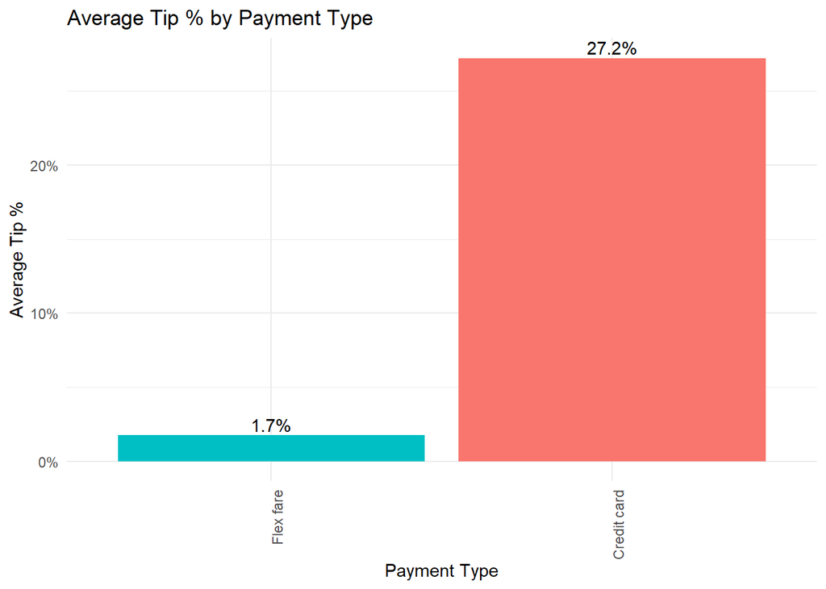

```r
#Payment type
taxi %>%
  group_by(payment_type_name) %>%
  summarise(
    avg_tip = mean(tip_percent_fare_amount, na.rm = TRUE),
    .groups = "drop"
  ) %>%
  ggplot(aes(x = reorder(payment_type_name, avg_tip), y = avg_tip, fill = payment_type_name)) +
  geom_col() +
  geom_text(aes(label = percent(avg_tip, accuracy = 0.1)), vjust = -0.3) +
  scale_y_continuous(labels = percent_format()) +
  labs(
    title = "Average Tip % by Payment Type",
    x = "Payment Type",
    y = "Average Tip %"
  ) +
  theme_minimal() +
  theme(axis.text.x = element_text(angle = 90, hjust = 1),
        legend.position = "none")
```

# Section: Tipping Behavior by Vendor

## Question: How does the median tip percentage vary across taxi vendors, and which vendor shows the highest tipping behavior?

## Anaswer: Median tip percentages differ across vendors. Helix has the highest median tip (~28.0%), followed by Creative Mobile Technologies (~24.2%) and Curb Mobility (~23.4%). Myle Technologies shows a median tip of 0%, which likely reflects missing or unrecorded tip data rather than actual absence of tipping. Overall, Helix demonstrates the strongest tipping behavior among the vendors.

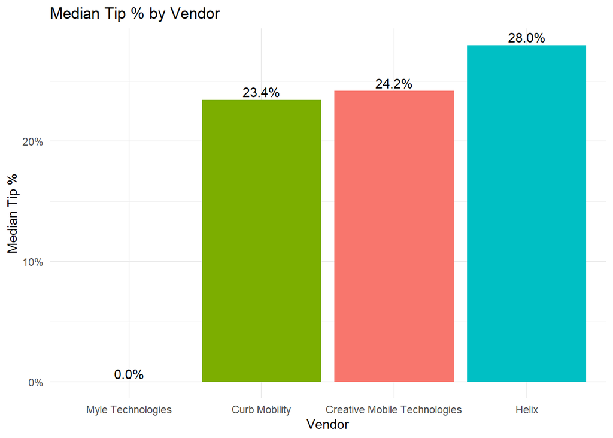

```r
#Vendor
taxi %>%
  group_by(Vendor_name) %>%
  summarise(
    median_tip = median(tip_percent_fare_amount, na.rm = TRUE),
    .groups = "drop"
  ) %>%
  ggplot(aes(x = reorder(Vendor_name, median_tip), y = median_tip, fill = Vendor_name)) +
  geom_col() +
  geom_text(aes(label = percent(median_tip, accuracy = 0.1)), vjust = -0.3) +
  scale_y_continuous(labels = percent_format()) +
  labs(
    title = "Median Tip % by Vendor",
    x = "Vendor",
    y = "Median Tip %"
  ) +
  theme_minimal() +
  theme(legend.position = "none")
```

# Section: Tipping and Fare Patterns by Passenger Count

## Question: How do median tip percentages and fare amounts vary with passenger count?

## Answer: Median tip percentages remain relatively stable for smaller groups (1–6 passengers), generally ranging from about 23% to 27%, with a slight peak around 5–6 passengers (~27%). However, tipping drops noticeably for larger groups (7–9 passengers), with a sharp decline at 7 passengers (~10.2%) and lower values for 8–9 passengers.

## Fare amounts show a different pattern: most rides with 1–4 passengers have a wide distribution with many outliers, indicating variability in trip distance and cost. As passenger count increases, fare variability decreases and fares become more concentrated, though generally higher for larger groups. Overall, while fares tend to rise and stabilize with more passengers, tipping behavior weakens for larger group sizes.

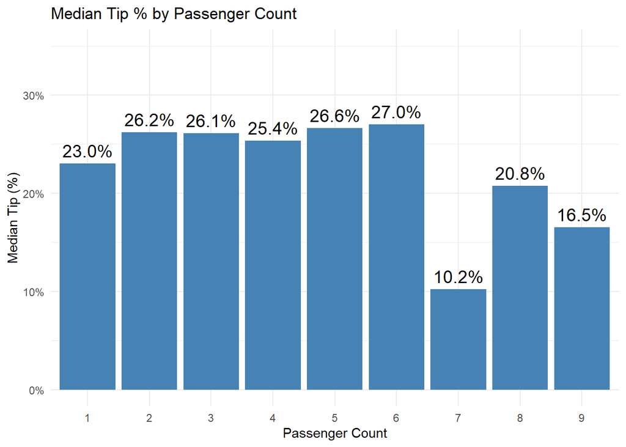

```r
taxi %>%
  filter(
    !is.na(passenger_count),
    passenger_count > 0
  ) %>%
  group_by(passenger_count) %>%
  summarise(
    median_tip_pct = median(tip_percent_fare_amount),
    .groups = "drop"
  ) %>%
  ggplot(aes(x = factor(passenger_count), y = median_tip_pct)) +
  geom_col(fill = "steelblue") +
  geom_text(
    aes(label = scales::percent(median_tip_pct, accuracy = 0.1)),
    vjust = -0.5,
    size = 5
  ) +
  scale_y_continuous(
    labels = scales::percent,
    limits = c(0, 0.35)   #increase upper limit
  ) +
  labs(
    title = "Median Tip % by Passenger Count",
    x = "Passenger Count",
    y = "Median Tip (%)"
  ) +
  theme_minimal()
```

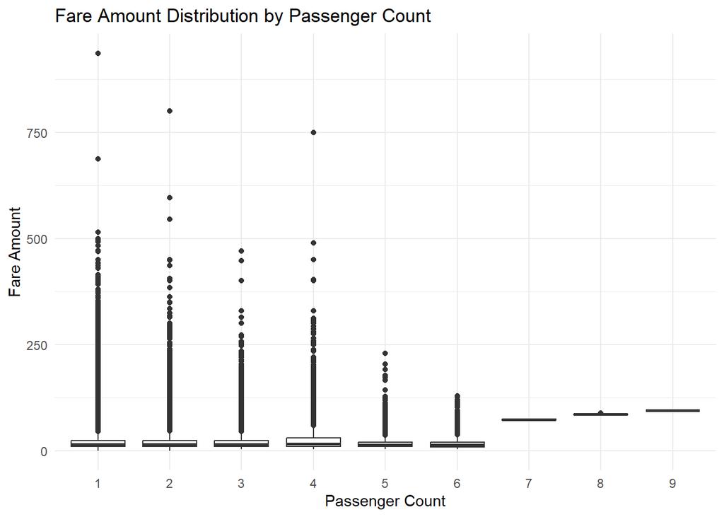

```r
taxi %>%
  filter(
    !is.na(passenger_count),
    passenger_count > 0
  ) %>%
  ggplot(aes(x = factor(passenger_count), y = fare_amount)) +
  geom_boxplot() +
  labs(
    title = "Fare Amount Distribution by Passenger Count",
    x = "Passenger Count",
    y = "Fare Amount"
  ) +
  theme_minimal()
```

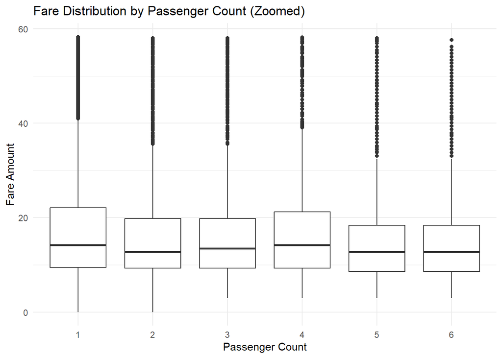

```r
taxi %>%
  filter(
    !is.na(passenger_count),
    passenger_count > 0,
    passenger_count < 7,
    fare_amount < quantile(fare_amount, 0.95)  #remove top 1% outliers
  ) %>%
  ggplot(aes(x = factor(passenger_count), y = fare_amount)) +
  geom_boxplot() +
  labs(
    title = "Fare Distribution by Passenger Count (Zoomed)",
    x = "Passenger Count",
    y = "Fare Amount"
  ) +
  theme_minimal()
```

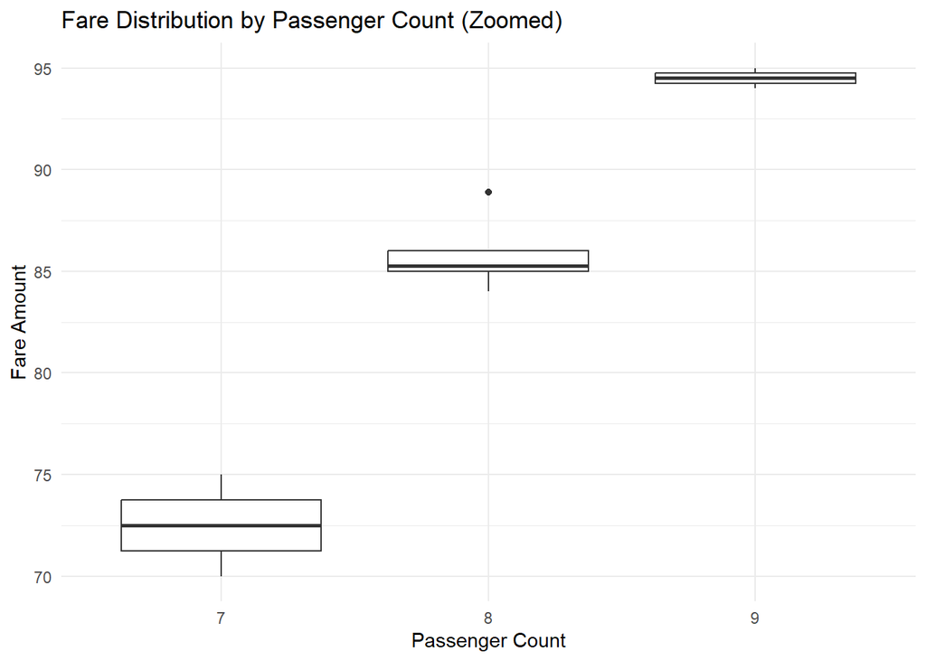

```r
taxi %>%
  filter(
    !is.na(passenger_count),
    passenger_count > 6
  ) %>%
  ggplot(aes(x = factor(passenger_count), y = fare_amount)) +
  geom_boxplot() +
  labs(
    title = "Fare Distribution by Passenger Count (Zoomed)",
    x = "Passenger Count",
    y = "Fare Amount"
  ) +
  theme_minimal()
```

# Section: Impact of Fare Components on Tipping Behavior

## Question: How do different fare components (fare amount, extras, taxes, and surcharges) influence median tip percentages?

## Answer: Tipping decreases as fare amount increases (30.1% to 15.2%) and similarly declines with total amount (27.8% to 22.1%). In contrast, higher extras are linked to higher tips (12.3% to 27.7%). Tolls and airport fees have minimal impact. Some fees (MTA tax, improvement, congestion surcharge) lack variation, limiting insights. Higher CBD congestion fees also show lower tipping (23.6% to 14.8%).

```r
fee_columns <- c("fare_amount", "extra", "mta_tax", "tolls_amount",
          "improvement_surcharge", "total_amount",
          "congestion_surcharge", "Airport_fee", "cbd_congestion_fee")

taxi <- taxi %>%
  mutate(across(all_of(fee_columns), ~case_when(
    . <= quantile(., 0.33, na.rm = TRUE) ~ "Low",
    . <= quantile(., 0.66, na.rm = TRUE) ~ "Mid",
    . >  quantile(., 0.66, na.rm = TRUE) ~ "High"
  ), .names = "{.col}_group"))

head(taxi)
```

```
## # A tibble: 6 × 35
##   VendorID tpep_pickup_datetime tpep_dropoff_datetime passenger_count
##      <int> <dttm>               <dttm>                          <dbl>
## 1        1 2025-01-22 15:34:30  2025-01-22 16:34:32                 1
## 2        2 2025-01-24 18:25:44  2025-01-24 18:37:40                 1
## 3        2 2025-01-02 12:02:02  2025-01-02 13:01:21                 1
## 4        2 2025-01-22 12:46:17  2025-01-22 13:02:06                 1
## 5        2 2025-01-26 07:19:09  2025-01-26 07:19:22                 1
## 6        2 2025-01-19 02:19:57  2025-01-19 02:21:14                 1
## # ℹ 31 more variables: trip_distance <dbl>, RatecodeID <int>,
## #   store_and_fwd_flag <chr>, PULocationID <int>, DOLocationID <int>,
## #   payment_type <int>, fare_amount <dbl>, extra <dbl>, mta_tax <dbl>,
## #   tip_amount <dbl>, tolls_amount <dbl>, improvement_surcharge <dbl>,
## #   total_amount <dbl>, congestion_surcharge <dbl>, Airport_fee <dbl>,
## #   cbd_congestion_fee <dbl>, month <int>, Vendor_name <chr>,
## #   Ratecode_name <chr>, payment_type_name <chr>, …
```

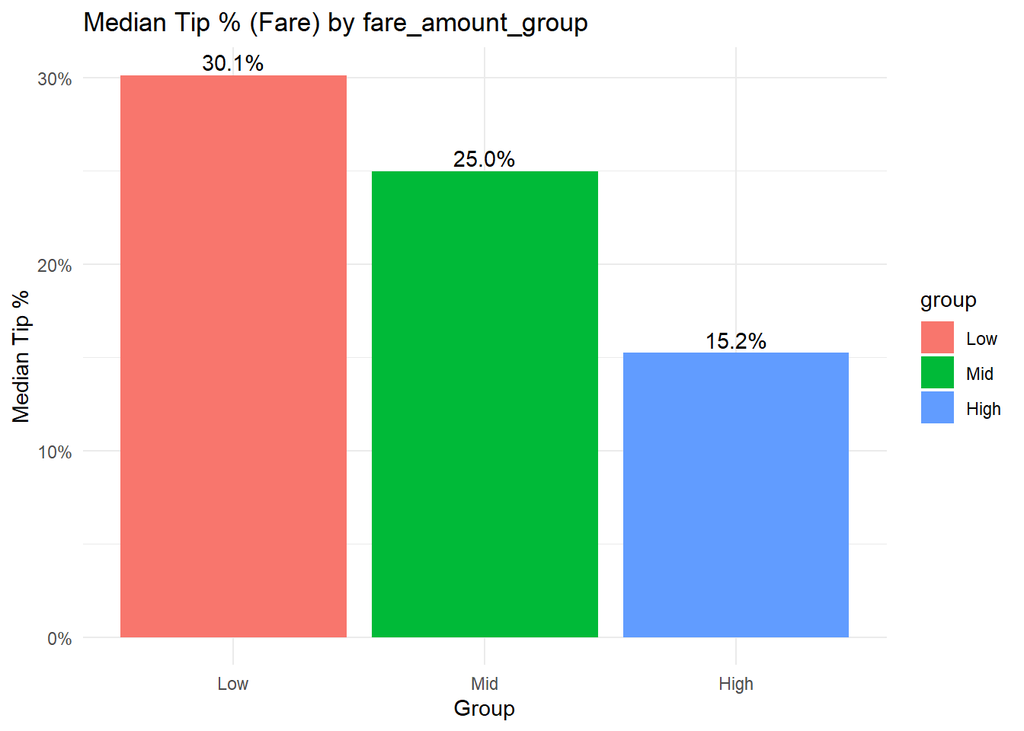

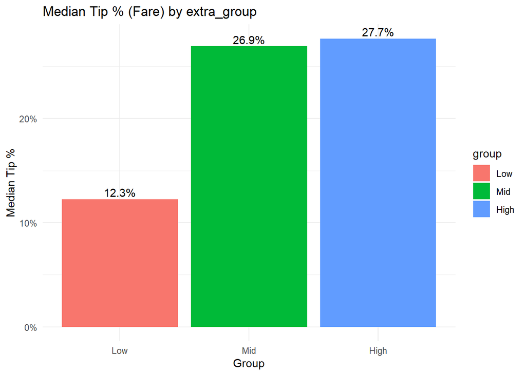

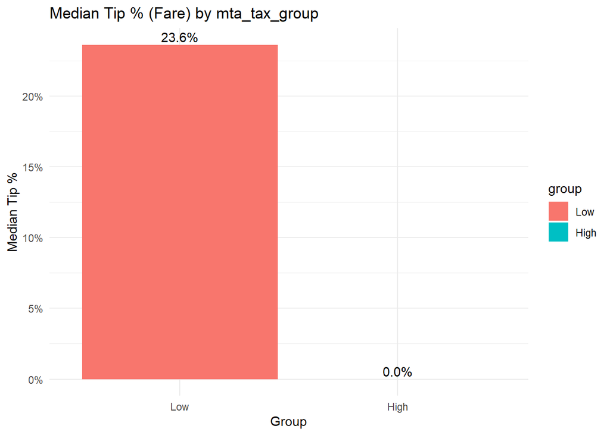

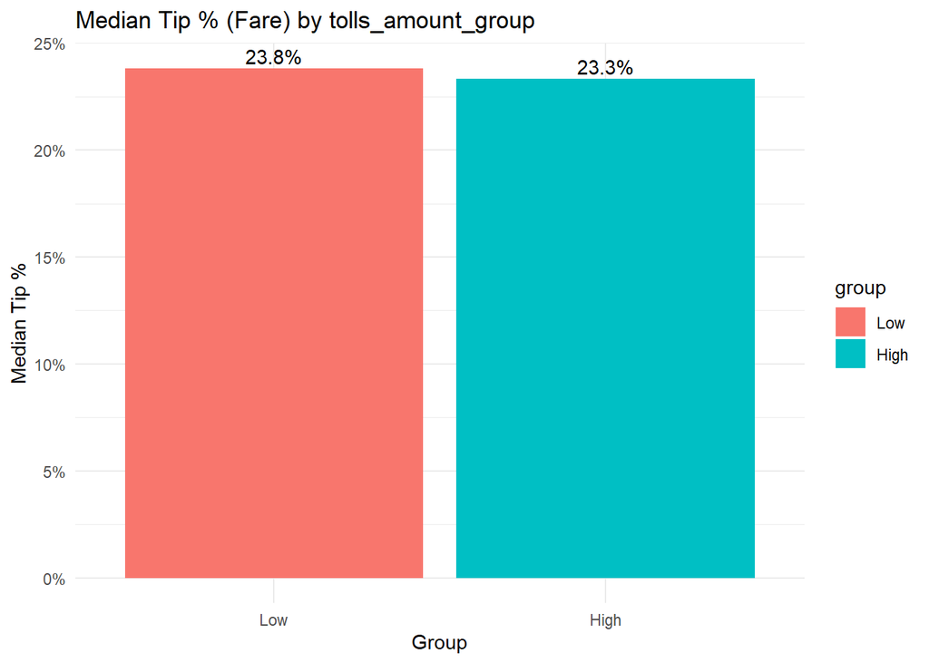

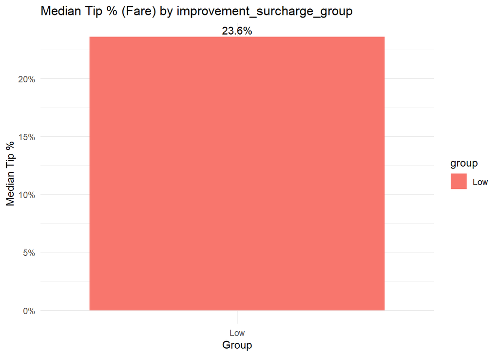

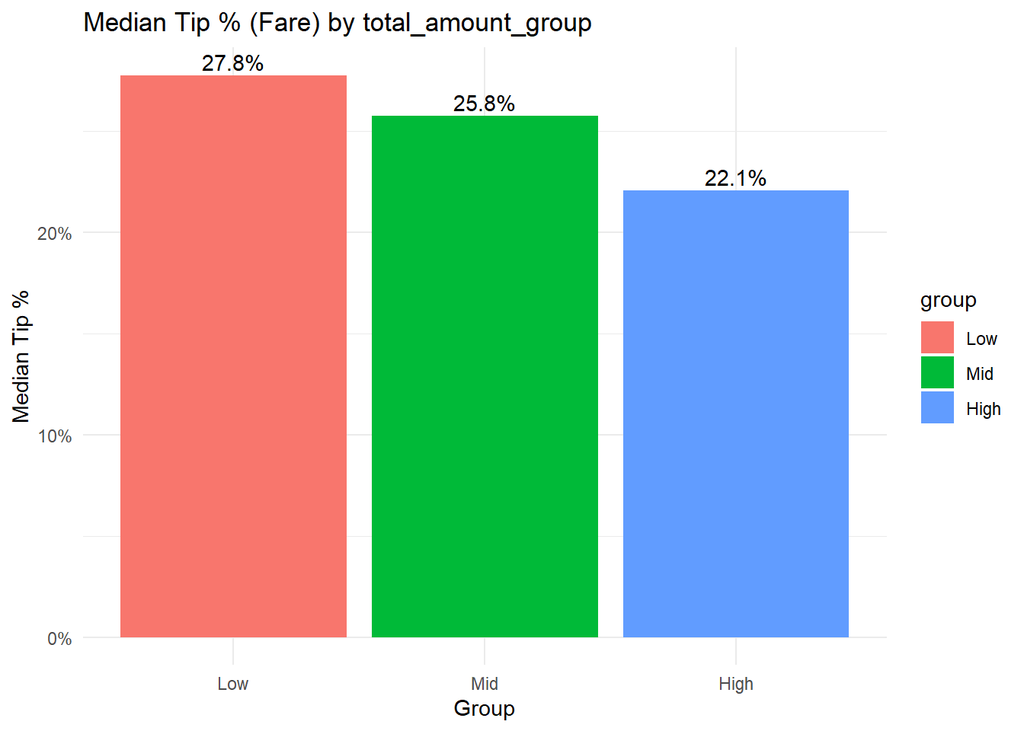

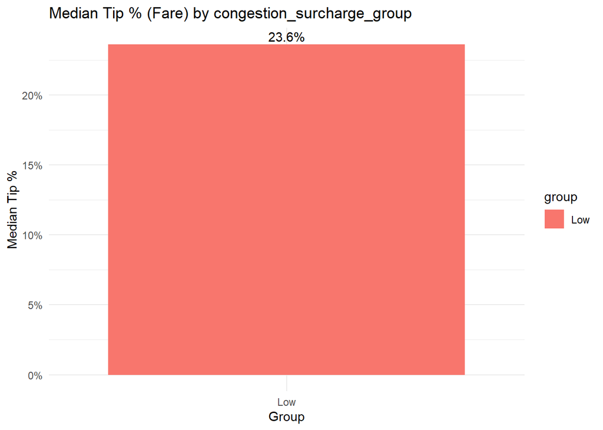

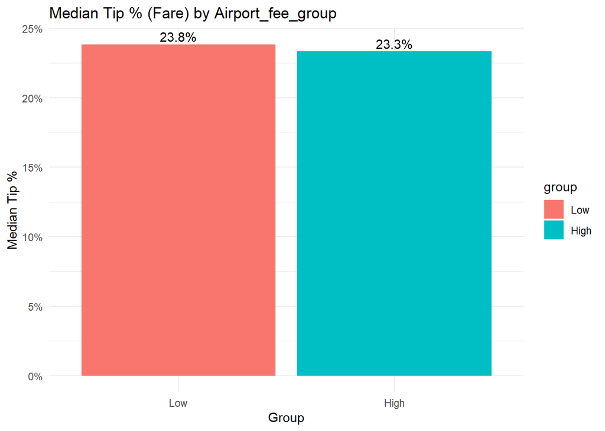

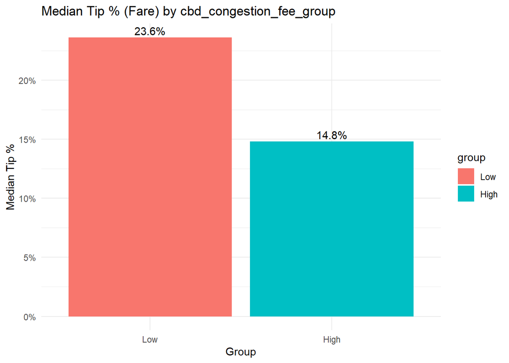

```r
group_cols <- paste0(fee_columns, "_group")

for (col in group_cols) {

  plot_data <- taxi %>%
    group_by(.data[[col]]) %>%
    summarise(
      median_tip = median(tip_percent_fare_amount, na.rm = TRUE),  # ✅ changed
      .groups = "drop"
    ) %>%
    rename(group = .data[[col]]) %>%
    mutate(
      group = factor(group, levels = c("Low", "Mid", "High"))
    )

  p <- ggplot(plot_data, aes(x = group, y = median_tip, fill = group)) +
    geom_col() +
    geom_text(
      aes(label = scales::percent(median_tip, accuracy = 0.1)),  # ✅ updated label
      vjust = -0.3
    ) +
    scale_y_continuous(labels = scales::percent_format()) +
    labs(
      title = paste("Median Tip % (Fare) by", col),  # ✅ updated title
      x = "Group",
      y = "Median Tip %"
    ) +
    theme_minimal()

  print(p)
}
```

# Import borough zone file

```r
#Getting Borough_Zone
#Borough_Zone = read.csv(file.choose(), header = TRUE, stringsAsFactors = TRUE)
Borough_Zone <- read.csv("C:/Users/sheng/Downloads/taxi_zone_lookup.csv")


head(Borough_Zone)
```

```
##   LocationID       Borough                    Zone service_zone
## 1          1           EWR          Newark Airport          EWR
## 2          2        Queens             Jamaica Bay    Boro Zone
## 3          3         Bronx Allerton/Pelham Gardens    Boro Zone
## 4          4     Manhattan           Alphabet City  Yellow Zone
## 5          5 Staten Island           Arden Heights    Boro Zone
## 6          6 Staten Island Arrochar/Fort Wadsworth    Boro Zone
```

```r
# Pickup
taxi <- taxi %>%
  left_join(Borough_Zone %>% select(LocationID, Borough, Zone),
            by = c("PULocationID" = "LocationID")) %>%
  mutate(pickup_location = paste(Borough, Zone, sep = " - ")) %>%
  select(-Borough, -Zone)

# Dropoff
taxi <- taxi %>%
  left_join(Borough_Zone %>% select(LocationID, Borough, Zone),
            by = c("DOLocationID" = "LocationID")) %>%
  mutate(dropoff_location = paste(Borough, Zone, sep = " - ")) %>%
  select(-Borough, -Zone)

#Checking Airport_fee > 0 when the pickup location Queens - LaGuardia Airport and Queens - JFK Airport
taxi %>% filter(!is.na(Airport_fee) & Airport_fee > 0) %>% distinct(pickup_location)
```

```
## # A tibble: 82 × 1
##    pickup_location
##    <chr>
##  1 Queens - JFK Airport
##  2 Queens - LaGuardia Airport
##  3 Queens - East Elmhurst
##  4 Unknown - N/A
##  5 Queens - Baisley Park
##  6 Queens - Jackson Heights
##  7 Manhattan - Times Sq/Theatre District
##  8 Manhattan - Midtown South
##  9 Manhattan - Midtown East
## 10 Queens - Flushing Meadows-Corona Park
## # ℹ 72 more rows
```

```r
taxi <- taxi %>%
  mutate(
    airport_fee_status = case_when(
      !is.na(Airport_fee) & Airport_fee > 0 &
        !(pickup_location %in% c("Queens - LaGuardia Airport",
                                "Queens - JFK Airport")) ~ "False Charge",

      !is.na(Airport_fee) & Airport_fee > 0 ~ "Valid Charge",

      TRUE ~ "No Charge"
    )
  )
```

# Section: Impact of Airport Fee Validity on Tipping Behavior

## Question: Does the presence of valid, invalid (false), or no airport fee affect median tip percentages?

## Answer: Median tip percentages are fairly similar across all airport fee categories, with only minor differences. Trips with a false airport charge show slightly higher median tips (25.9%), compared to no charge (23.8%) and valid charges (23.3%). However, the differences are small, suggesting that airport fees (valid and incorrectly applied) do not meaningfully influence tipping behavior.

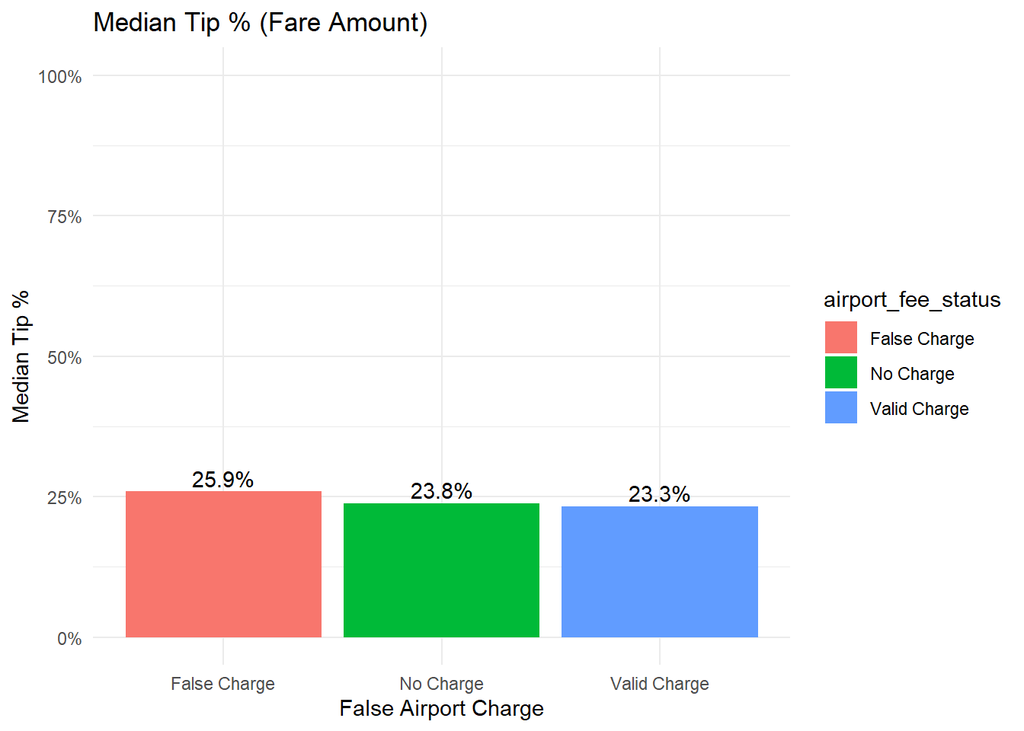

```r
taxi %>%
  group_by(airport_fee_status) %>%
  summarise(median_tip = median(tip_percent_fare_amount, na.rm = TRUE),
            .groups = "drop") %>%
  ggplot(aes(x = airport_fee_status, y = median_tip, fill = airport_fee_status)) +
  geom_col() +
  geom_text(
    aes(label = scales::percent(median_tip, accuracy = 0.1)),
    vjust = -0.3
  ) +
  scale_y_continuous(
    labels = scales::percent,
    limits = c(0, 1)
  ) +
  labs(
    title = "Median Tip % (Fare Amount)",
    x = "False Airport Charge",
    y = "Median Tip %"
  ) +
  theme_minimal()
```

# Section: Tipping Behavior by Pickup Borough

## Question: How does median tip percentage vary across different pickup boroughs?

## Answer: Median tip percentages vary notably by pickup borough. Manhattan (24.8%) and Queens (21.1%) show the highest tipping rates among major boroughs, indicating stronger tipping behavior in these areas. EWR (12.6%) has noticeably lower median tips. Meanwhile, Bronx, Brooklyn, and Staten Island show 0%, which likely reflects missing or unrecorded tip data rather than true absence of tipping. The “Unknown” category (25.4%) and “N/A” (7.3%) but may not be reliable due to unclear location data. Overall, tipping is strongest in high-traffic, central areas like Manhattan and Queens.

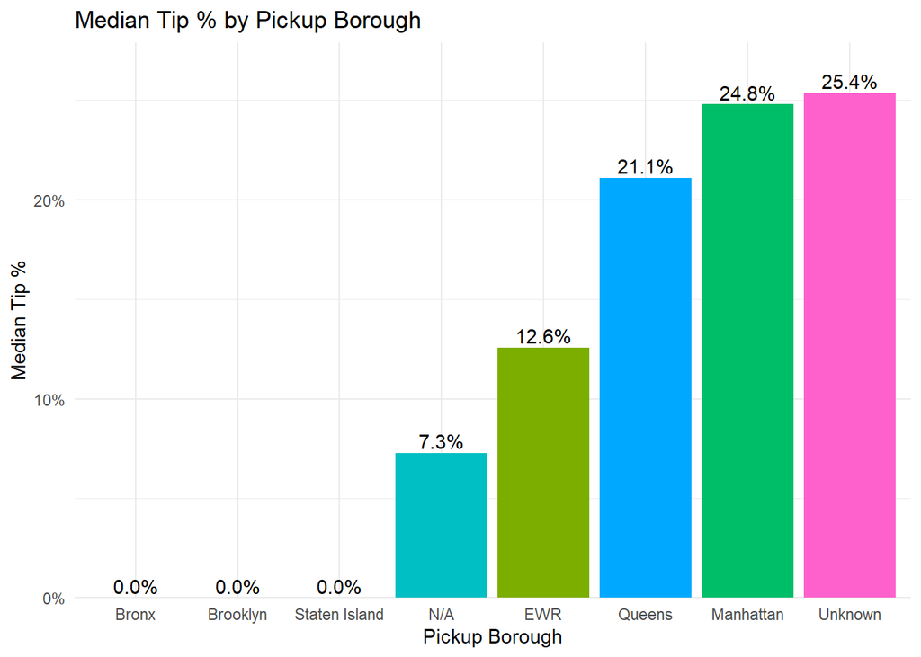

```r
taxi %>%
  mutate(
    pickup_borough = sub(" -.*", "", pickup_location)
  ) %>%
  group_by(pickup_borough) %>%
  summarise(
    median_tip = median(tip_percent_fare_amount, na.rm = TRUE),
    .groups = "drop"
  ) %>%
  ggplot(aes(x = reorder(pickup_borough, median_tip), y = median_tip, fill = pickup_borough)) +
  geom_col() +
  geom_text(aes(label = scales::percent(median_tip, accuracy = 0.1)), vjust = -0.3) +
  scale_y_continuous(
    labels = scales::percent_format(),
    expand = expansion(mult = c(0, 0.1))
  ) +
  labs(
    title = "Median Tip % by Pickup Borough",
    x = "Pickup Borough",
    y = "Median Tip %"
  ) +
  theme_minimal() +
  theme(legend.position = "none")
```

# Section: Tipping Behavior by Dropoff Borough

## Question: How does median tip percentage vary across different dropoff boroughs?

## Answer: Median tip percentages vary across dropoff boroughs in a pattern similar to pickup locations. Manhattan (24.8%) and EWR (23.1%) show relatively high tipping rates, followed by Queens (13.2%) with moderate levels. Staten Island (2.2%) is much lower, while Bronx and Brooklyn show 0%, likely due to missing or unrecorded tip data rather than actual behavior. The “Unknown” category (25.6%) and “N/A” (16.1%) andmay not be reliable due to unclear location data. Overall, higher tipping is concentrated in major transit and central areas like Manhattan and airport routes.

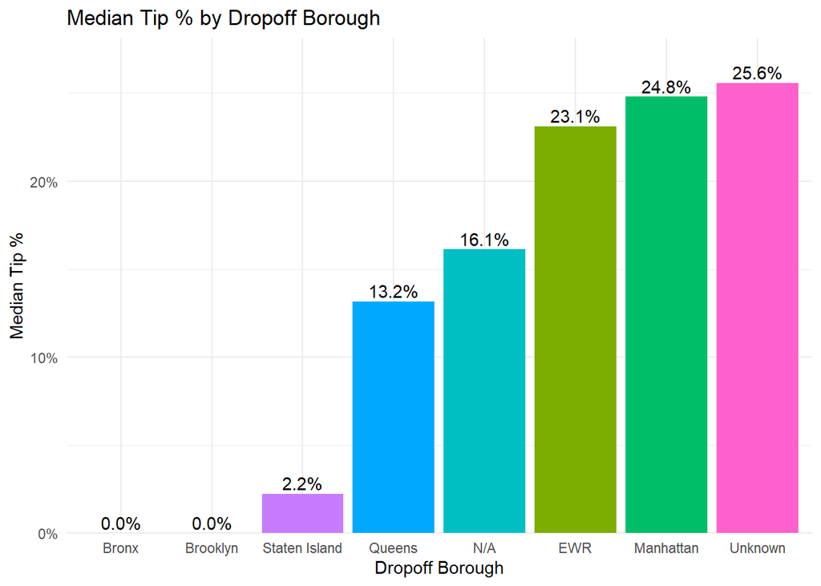

```r
taxi %>%
  mutate(
    dropoff_borough = sub(" -.*", "", dropoff_location)
  ) %>%
  group_by(dropoff_borough) %>%
  summarise(
    median_tip = median(tip_percent_fare_amount, na.rm = TRUE),
    .groups = "drop"
  ) %>%
  ggplot(aes(x = reorder(dropoff_borough, median_tip), y = median_tip, fill = dropoff_borough)) +
  geom_col() +
  geom_text(aes(label = scales::percent(median_tip, accuracy = 0.1)), vjust = -0.3) +
  scale_y_continuous(
    labels = scales::percent_format(),
    expand = expansion(mult = c(0, 0.1))
  ) +
  labs(
    title = "Median Tip % by Dropoff Borough",
    x = "Dropoff Borough",
    y = "Median Tip %"
  ) +
  theme_minimal() +
  theme(legend.position = "none")
```

```r
#checking false cbd_congestion_fee
taxi %>%
  filter(
    as.Date(tpep_pickup_datetime) < as.Date("2025-01-05") &
    !is.na(cbd_congestion_fee) &
    cbd_congestion_fee != 0
  )
```

```
## # A tibble: 19 × 38
##    VendorID tpep_pickup_datetime tpep_dropoff_datetime passenger_count
##       <int> <dttm>               <dttm>                          <dbl>
##  1        2 2025-01-04 17:50:45  2025-01-04 18:00:38                 1
##  2        2 2025-01-04 17:58:45  2025-01-04 18:04:23                 1
##  3        2 2025-01-04 17:49:17  2025-01-04 18:13:32                 2
##  4        2 2025-01-04 17:58:12  2025-01-04 18:19:16                 1
##  5        2 2025-01-04 17:56:25  2025-01-04 18:06:42                 1
##  6        2 2025-01-04 17:43:16  2025-01-04 18:19:01                 1
##  7        2 2025-01-04 17:55:02  2025-01-04 18:21:23                 1
##  8        2 2025-01-04 17:50:46  2025-01-04 18:11:37                 2
##  9        2 2025-01-04 17:56:32  2025-01-04 18:07:36                 1
## 10        2 2025-01-04 17:58:03  2025-01-04 18:09:02                 1
## 11        2 2025-01-04 17:46:28  2025-01-04 18:04:12                 1
## 12        2 2025-01-04 17:38:36  2025-01-04 18:10:35                 2
## 13        2 2025-01-04 17:55:39  2025-01-04 18:01:00                 1
## 14        2 2025-01-04 17:55:53  2025-01-04 18:02:11                 1
## 15        2 2025-01-04 17:44:39  2025-01-04 18:09:48                 1
## 16        2 2025-01-04 17:46:51  2025-01-04 18:09:00                 1
## 17        2 2025-01-04 17:55:08  2025-01-04 18:07:23                 1
## 18        2 2025-01-04 17:59:18  2025-01-04 18:09:42                 1
## 19        2 2025-01-04 17:52:57  2025-01-04 18:02:08                 1
## # ℹ 34 more variables: trip_distance <dbl>, RatecodeID <int>,
## #   store_and_fwd_flag <chr>, PULocationID <int>, DOLocationID <int>,
## #   payment_type <int>, fare_amount <dbl>, extra <dbl>, mta_tax <dbl>,
## #   tip_amount <dbl>, tolls_amount <dbl>, improvement_surcharge <dbl>,
## #   total_amount <dbl>, congestion_surcharge <dbl>, Airport_fee <dbl>,
## #   cbd_congestion_fee <dbl>, month <int>, Vendor_name <chr>,
## #   Ratecode_name <chr>, payment_type_name <chr>, …
```

# Section: Tipping Patterns by Pickup–Dropoff Borough Pair

## Question: How does median tip percentage vary across dropoff boroughs within each pickup borough?

## Answer: Several patterns stand out:

### For Manhattan pickups, median tip percentages are generally highest for dropoffs to Manhattan (25.2%), EWR (23.5%), and Queens (23.1%), while dropoffs to Bronx (0%), Staten Island (6.7%) are much lower.

### For Queens pickups, tipping is also relatively strong for dropoffs to Manhattan (23.3%), and EWR (22.5%), but lower for Staten Island and near zero for some local categories.

### For EWR pickups, tips increase from EWR (11.5%) to Unknown (20.2%) to Manhattan (23.6%), suggesting airport-origin trips to central destinations tend to have stronger tipping.

### For Unknown pickups, the highest tips appear for dropoffs to Manhattan, Staten Island, and Unknown (around 25%–26%), while EWR is much lower.

### For Brooklyn, Bronx, and Staten Island pickups, many categories show 0%, which likely reflects very small sample sizes, missing values, or unrecorded tips, so these should be interpreted cautiously.

## Overall, the strongest and most consistent tipping appears on trips involving Manhattan, Queens, and EWR, especially when trips connect major commercial or airport areas. In contrast, many outer-borough pickup/dropoff combinations appear sparse and may not be reliable enough for strong conclusions.

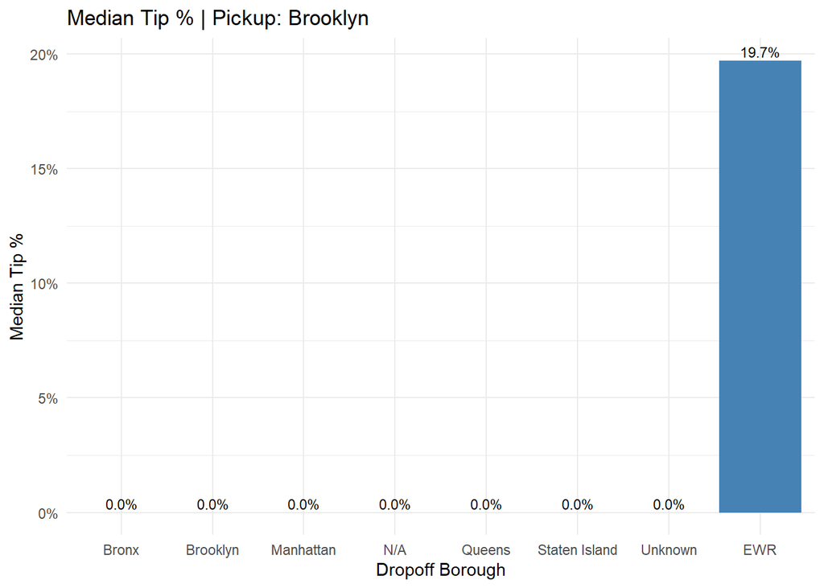

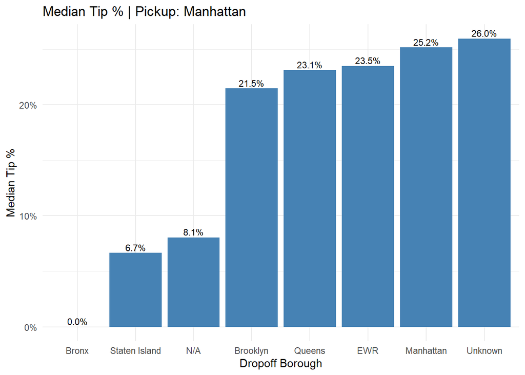

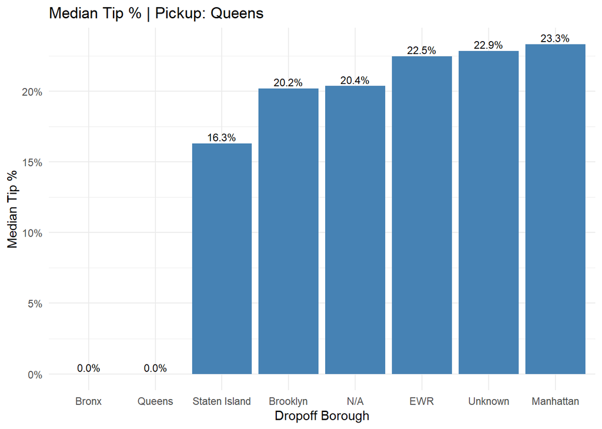

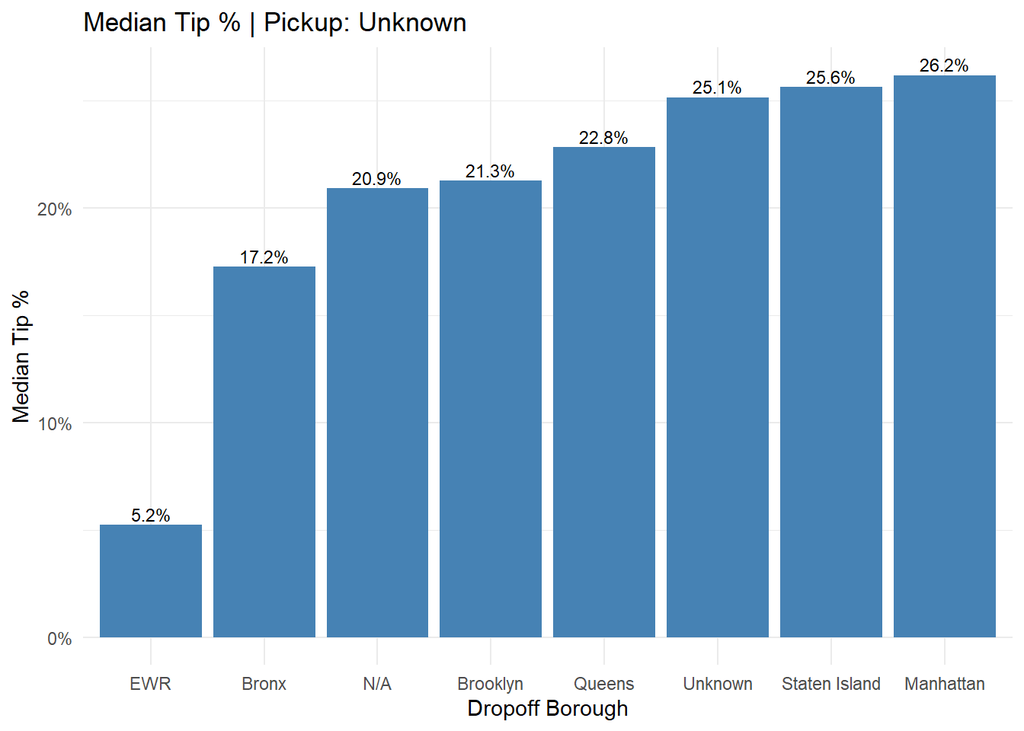

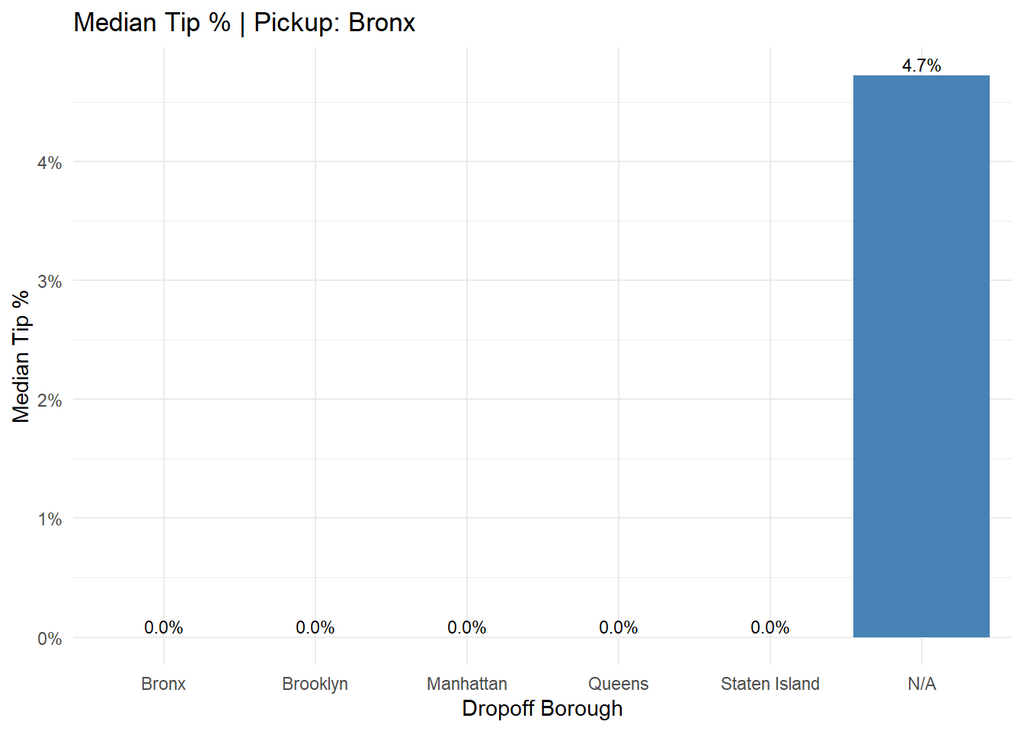

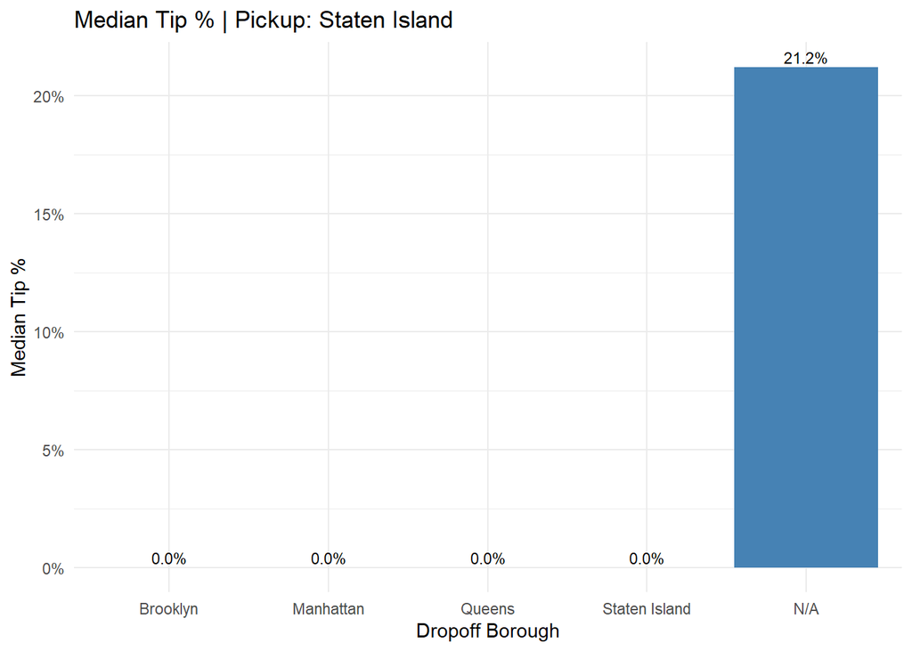

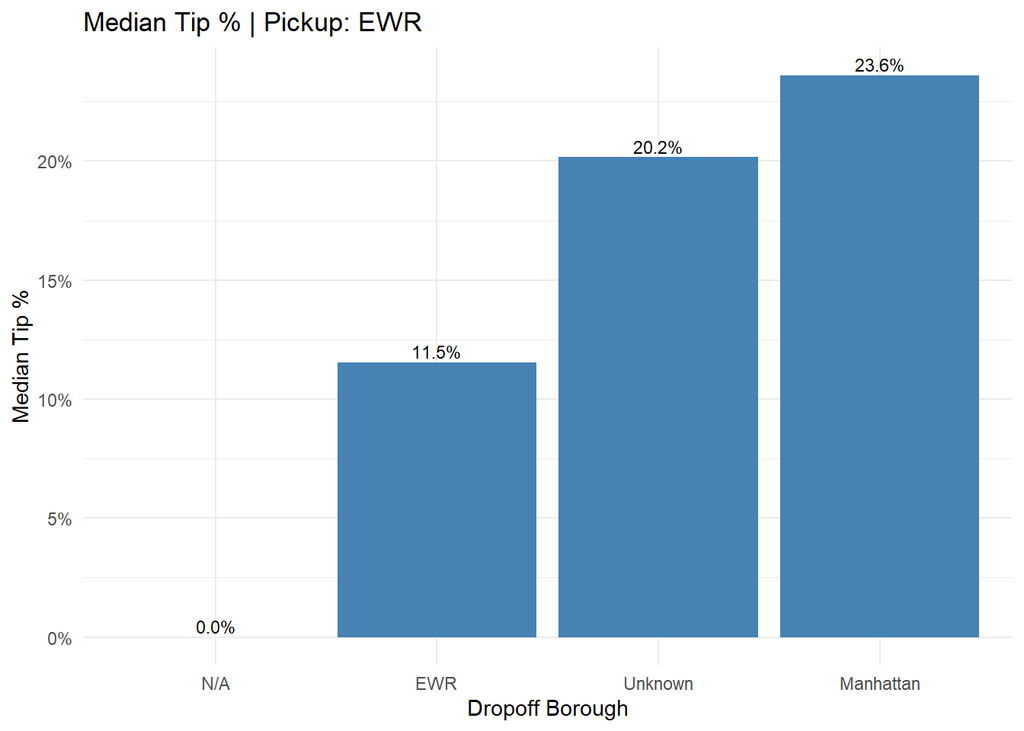

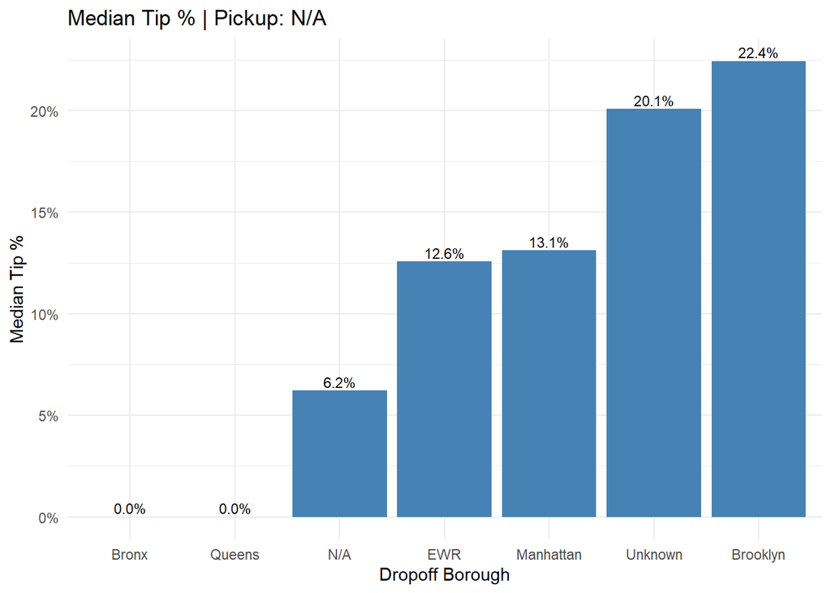

```r
# create borough columns once
taxi <- taxi %>%
  mutate(
    pickup_borough = sub(" -.*", "", pickup_location),
    dropoff_borough = sub(" -.*", "", dropoff_location)
  )

# loop through each pickup borough
for (p in unique(taxi$pickup_borough)) {

  plot_data <- taxi %>%
    filter(pickup_borough == p) %>%
    group_by(dropoff_borough) %>%
    summarise(
      median_tip = median(tip_percent_fare_amount, na.rm = TRUE),
      n = n(),
      .groups = "drop"
    )

  p_plot <- ggplot(plot_data, aes(x = reorder(dropoff_borough, median_tip), y = median_tip)) +
    geom_col(fill = "steelblue") +
    geom_text(
      aes(label = scales::percent(median_tip, accuracy = 0.1)),
      vjust = -0.3,
      size = 3
    ) +
    scale_y_continuous(labels = scales::percent_format()) +
    labs(
      title = paste("Median Tip % | Pickup:", p),
      x = "Dropoff Borough",
      y = "Median Tip %"
    ) +
    theme_minimal()

  print(p_plot)
}
```

# Section: Tipping and Fare Patterns by Rate Code

## Question: How do median tip percentages and median fare amounts vary across different rate codes?

## Answer: Median tip percentages vary moderately across rate codes, while median fares differ substantially. Standard trips have the highest median tip percentage (27.0%) despite also having the lowest median fare ($12.80), suggesting riders tip a larger percentage on regular lower-cost trips. JFK and Newark trips show slightly lower median tip percentages (23.1% and 23.2%) but much higher median fares ($70.00 and $85.30). Negotiated (median fare $70) and Nassau/Westchester trips have the lowest nonzero median tip percentages (20.2% and 20.4%), even though Nassau/Westchester has the highest median fare ($104.50). The Unknown rate code shows a 0% median tip and a relatively low fare ($19.73), which likely reflects missing or unreliable data. Overall, higher-fare rate codes tend to have lower tip percentages, reinforcing the earlier pattern that passengers tip proportionally less on more expensive trips.

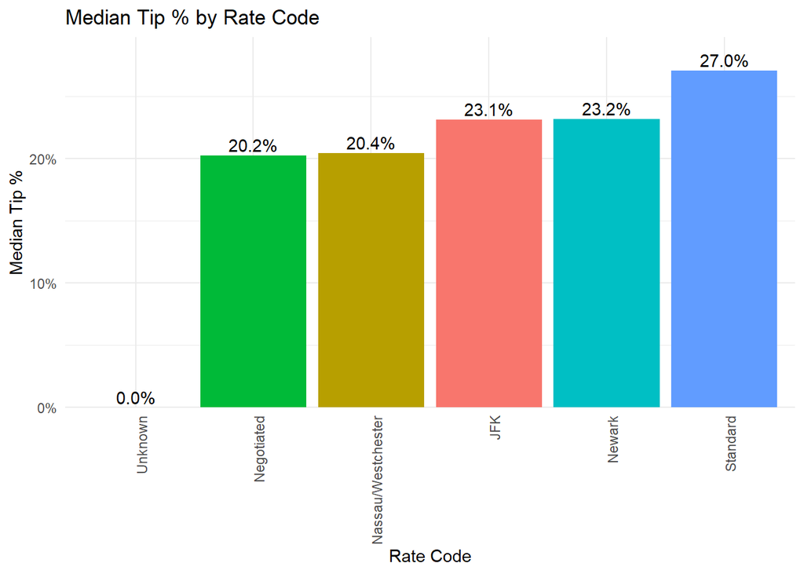

```r
#Rate code
taxi %>%
  group_by(Ratecode_name) %>%
  summarise(
    median_tip = median(tip_percent_fare_amount, na.rm = TRUE),
    .groups = "drop"
  ) %>%
  ggplot(aes(x = reorder(Ratecode_name, median_tip), y = median_tip, fill = Ratecode_name)) +
  geom_col() +
  geom_text(aes(label = percent(median_tip, accuracy = 0.1)), vjust = -0.3) +
  scale_y_continuous(labels = percent_format(), expand = expansion(mult = c(0, 0.1))) +
  labs(
    title = "Median Tip % by Rate Code",
    x = "Rate Code",
    y = "Median Tip %"
  ) +
  theme_minimal() +
  theme(axis.text.x = element_text(angle = 90, hjust = 1),
        legend.position = "none")
```

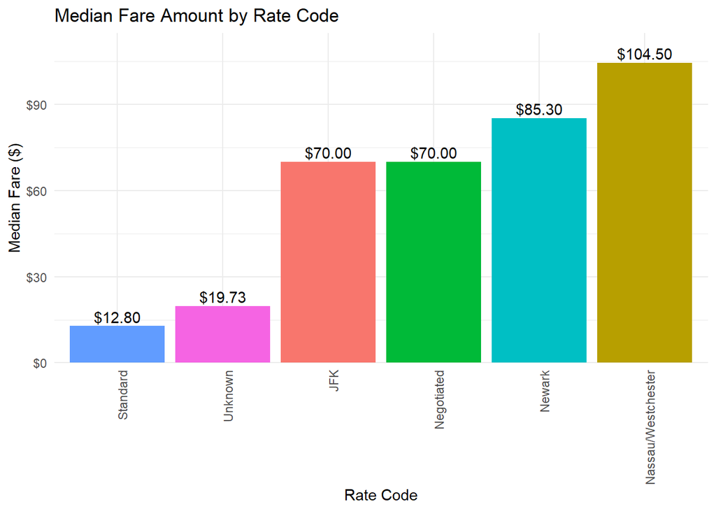

```r
taxi %>%
  group_by(Ratecode_name) %>%
  summarise(
    median_fare = median(fare_amount, na.rm = TRUE),
    .groups = "drop"
  ) %>%
  ggplot(aes(x = reorder(Ratecode_name, median_fare), y = median_fare, fill = Ratecode_name)) +
  geom_col() +
  geom_text(aes(label = scales::dollar(median_fare)), vjust = -0.3) +
  scale_y_continuous(labels = scales::dollar_format(),
                     expand = expansion(mult = c(0, 0.1))) +
  labs(
    title = "Median Fare Amount by Rate Code",
    x = "Rate Code",
    y = "Median Fare ($)"
  ) +
  theme_minimal() +
  theme(axis.text.x = element_text(angle = 90, hjust = 1),
        legend.position = "none")
```

# Creating Time Related Features.

```r
library(dplyr)

taxi <- taxi %>%
  mutate(
    trip_duration_mins = as.numeric(difftime(
      tpep_dropoff_datetime,
      tpep_pickup_datetime,
      units = "mins"
    )),

    weekday = factor(
      weekdays(tpep_pickup_datetime),
      levels = c("Monday", "Tuesday", "Wednesday", "Thursday", "Friday", "Saturday", "Sunday")
    ),

    month = factor(
      months(tpep_pickup_datetime),
      levels = month.name
    ),

    pickup_hour = as.integer(format(tpep_pickup_datetime, "%H")),

    pickup_time_of_day = case_when(
      pickup_hour >= 5  & pickup_hour < 12 ~ "Morning",
      pickup_hour >= 12 & pickup_hour < 17 ~ "Afternoon",
      pickup_hour >= 17 & pickup_hour < 21 ~ "Evening",
      TRUE ~ "Night"
    )
  )

taxi <- taxi %>%
  mutate(
    pickup_time_of_day = factor(
      pickup_time_of_day,
      levels = c("Morning", "Afternoon", "Evening", "Night")
    )
  )
```

# Section: Tipping Patterns by Pickup Borough, Dropoff Borough, and Time of Day